# Classification Models

Bronson Bagwell

2024-01-24

```r
library(ROCR)
library(caret)
library(dplyr)
library(ggplot2)
library(tidyverse)
```

```r
df <- read.csv("GraduateAdmission.csv")

str(df)
names(df)

df <- df[, -which(names(df) == "Serial.No.")]
```

# 1. Prepare the data by converting some of the features to factors.

```r
cols_to_factorize <- c("UnivRating","Research", "Admit")

for (col in cols_to_factorize) {
  df[[col]] <- as.factor(df[[col]])
}

str(df)
```

```
## 'data.frame':    400 obs. of  8 variables:
##  $ GRE       : int  337 324 316 322 314 330 321 308 302 323 ...
##  $ TOEFL     : int  118 107 104 110 103 115 109 101 102 108 ...
##  $ UnivRating: Factor w/ 5 levels "1","2","3","4",..: 4 4 3 3 2 5 3 2 1 3 ...
##  $ SOP       : num  4.5 4 3 3.5 2 4.5 3 3 2 3.5 ...
##  $ LOR       : num  4.5 4.5 3.5 2.5 3 3 4 4 1.5 3 ...
##  $ CGPA      : num  9.65 8.87 8 8.67 8.21 9.34 8.2 7.9 8 8.6 ...
##  $ Research  : Factor w/ 2 levels "0","1": 2 2 2 2 1 2 2 1 1 1 ...
##  $ Admit     : Factor w/ 2 levels "0","1": 2 2 2 2 2 2 2 2 1 1 ...
```

```r
names(df)
```

```
## [1] "GRE"        "TOEFL"      "UnivRating" "SOP"        "LOR"
## [6] "CGPA"       "Research"   "Admit"
```

# 2. Produce numerical summaries of each feature.

```r
summary(df)
```

```
##       GRE            TOEFL       UnivRating      SOP           LOR
##  Min.   :290.0   Min.   : 92.0   1: 26      Min.   :1.0   Min.   :1.000
##  1st Qu.:308.0   1st Qu.:103.0   2:107      1st Qu.:2.5   1st Qu.:3.000
##  Median :317.0   Median :107.0   3:133      Median :3.5   Median :3.500
##  Mean   :316.8   Mean   :107.4   4: 74      Mean   :3.4   Mean   :3.453
##  3rd Qu.:325.0   3rd Qu.:112.0   5: 60      3rd Qu.:4.0   3rd Qu.:4.000
##  Max.   :340.0   Max.   :120.0              Max.   :5.0   Max.   :5.000
##       CGPA       Research Admit
##  Min.   :6.800   0:181    0: 90
##  1st Qu.:8.170   1:219    1:310
##  Median :8.610
##  Mean   :8.599
##  3rd Qu.:9.062
##  Max.   :9.920
```

# 3. Draw the side by side boxplot of CGPA by Admit. Describe your finding.

Students with Higher Undergraduate CGPA (out of 10) tend to get accepted to Graduate School at a higher rate. Admission Group CGPA Mean of 8.79 vs the Non-admission CGPA mean of 7.95.

```r
summary_stats <- df %>%
  group_by(Admit) %>%
  summarize(
    Mean = mean(CGPA),
    Median = median(CGPA),
    Q1 = quantile(CGPA, 0.25),
    Q3 = quantile(CGPA, 0.75)
  )

print(summary_stats)
```

```
## # A tibble: 2 × 5
##   Admit  Mean Median    Q1    Q3
##   <fct> <dbl>  <dbl> <dbl> <dbl>
## 1 0      7.95   7.96  7.65  8.24
## 2 1      8.79   8.76  8.42  9.14
```

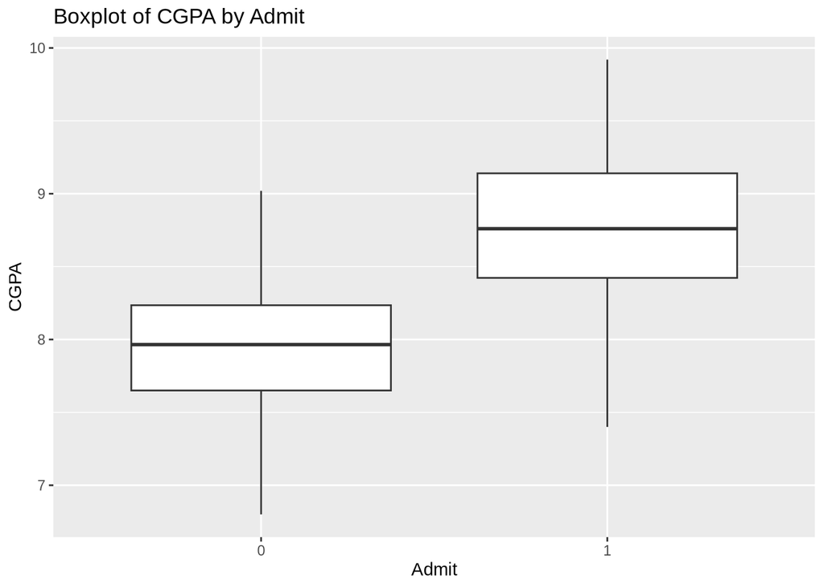

```r
ggplot(df, aes(x = Admit, y = CGPA)) +
  geom_boxplot() +
  labs(title = "Boxplot of CGPA by Admit",
       x = "Admit",
       y = "CGPA")
```

# 4. What’s the proportion of each class Admit (category)? What’s the benchmark accuracy?

0 - 90(22.5%)

1 - 310(77.5%)

Benchmark Accuracy 77.5%

```r
table(df$Admit)
```

```
##
##   0   1
##  90 310
```

```r
prop.table(table(df$Admit))
```

```
##
##     0     1
## 0.225 0.775
```

# 5. Split the data into a 80% training set and a 20% test set. Use set.seed(7332.01) for reproducibility

```r
set.seed(7332.01)

Index <- createDataPartition(df$Admit,p=0.8,list=FALSE)
trdata <- df[Index,]
tsdata <- df[-Index,]
head(trdata)
```

```
##   GRE TOEFL UnivRating SOP LOR CGPA Research Admit
## 2 324   107          4 4.0 4.5 8.87        1     1
## 3 316   104          3 3.0 3.5 8.00        1     1
## 4 322   110          3 3.5 2.5 8.67        1     1
## 5 314   103          2 2.0 3.0 8.21        0     1
## 6 330   115          5 4.5 3.0 9.34        1     1
## 7 321   109          3 3.0 4.0 8.20        1     1
```

```r
head(tsdata)
```

```
##    GRE TOEFL UnivRating SOP LOR CGPA Research Admit
## 1  337   118          4 4.5 4.5 9.65        1     1
## 14 307   109          3 4.0 3.0 8.00        1     0
## 22 325   114          4 3.0 2.0 8.40        0     1
## 26 340   120          5 4.5 4.5 9.60        1     1
## 29 295    93          1 2.0 2.0 7.20        0     0
## 33 338   118          4 3.0 4.5 9.40        1     1
```

# 6. Find the logistic model with all its predictors in the model significant using the training data set

```r
# Using all predictors
logisticm <- glm(Admit ~ ., data = trdata, family = "binomial")
summary(logisticm)
```

```
##
## Call:
## glm(formula = Admit ~ ., family = "binomial", data = trdata)
##
## Coefficients:
##               Estimate Std. Error z value Pr(>|z|)
## (Intercept) -4.464e+01  8.485e+00  -5.261 1.43e-07 ***
## GRE          6.644e-02  3.378e-02   1.967 0.049223 *
## TOEFL       -4.181e-05  6.997e-02  -0.001 0.999523
## UnivRating2  1.206e+00  9.290e-01   1.298 0.194380
## UnivRating3  9.741e-01  9.961e-01   0.978 0.328091
## UnivRating4  1.314e+00  1.323e+00   0.993 0.320604
## UnivRating5  1.565e+01  1.343e+03   0.012 0.990700
## SOP          7.568e-02  3.010e-01   0.251 0.801463
## LOR          7.098e-01  3.284e-01   2.161 0.030689 *
## CGPA         2.591e+00  7.621e-01   3.400 0.000673 ***
## Research1    2.051e-01  4.155e-01   0.494 0.621489
## ---
## Signif. codes:  0 '***' 0.001 '**' 0.01 '*' 0.05 '.' 0.1 ' ' 1
##
## (Dispersion parameter for binomial family taken to be 1)
##
##     Null deviance: 341.22  on 319  degrees of freedom
## Residual deviance: 176.72  on 309  degrees of freedom
## AIC: 198.72
##
## Number of Fisher Scoring iterations: 18
```

```r
# Excluding TOEFL, UnivRating, SOP, and Research
flogisticm <- glm(Admit ~ . - TOEFL - UnivRating - SOP - Research, data = trdata, family = "binomial")
summary(flogisticm)
```

```
##
## Call:
## glm(formula = Admit ~ . - TOEFL - UnivRating - SOP - Research,
##     family = "binomial", data = trdata)
##
## Coefficients:
##              Estimate Std. Error z value Pr(>|z|)
## (Intercept) -46.37074    7.76385  -5.973 2.33e-09 ***
## GRE           0.07109    0.02824   2.517  0.01184 *
## LOR           0.84341    0.29572   2.852  0.00434 **
## CGPA          2.74230    0.69290   3.958 7.57e-05 ***
## ---
## Signif. codes:  0 '***' 0.001 '**' 0.01 '*' 0.05 '.' 0.1 ' ' 1
##
## (Dispersion parameter for binomial family taken to be 1)
##
##     Null deviance: 341.22  on 319  degrees of freedom
## Residual deviance: 180.05  on 316  degrees of freedom
## AIC: 188.05
##
## Number of Fisher Scoring iterations: 6
```

```r
round(coef(flogisticm), 5)
```

```
## (Intercept)         GRE         LOR        CGPA
##   -46.37074     0.07109     0.84341     2.74230
```

# 7. Interpret the logistic model coefficients found in question #6 ?

For Every One Unit increase in GRE the Log odds Admission goes up by .07109 All others constant

For Every One Unit increase in LOR the Log odds Admission goes up by .84341 All others constant

For Every One Unit increase in CGPA the Log odds Admission goes up by 2.74230 All others constant

# 8. Predict the testing dataset using the model you found in question #6, compute the confusion matrix and discuss the overall accuracy, misclassification, Sensitivity and Specificity?

Overall accuracy using the test set 0.8875

Overall Misclassification in test Data 0.1125

Overall Sensitivity using the test set 0.9516

Overall Specificity in test Data 0.6667

```r
pred_probts <- predict(flogisticm,tsdata,type="response")
pred_cts  <- ifelse(pred_probts>0.5,1,0)
head(pred_cts)
```

```
##  1 14 22 26 29 33
##  1  0  1  1  0  1
```

```r
head(tsdata)
```

```
##    GRE TOEFL UnivRating SOP LOR CGPA Research Admit
## 1  337   118          4 4.5 4.5 9.65        1     1
## 14 307   109          3 4.0 3.0 8.00        1     0
## 22 325   114          4 3.0 2.0 8.40        0     1
## 26 340   120          5 4.5 4.5 9.60        1     1
## 29 295    93          1 2.0 2.0 7.20        0     0
## 33 338   118          4 3.0 4.5 9.40        1     1
```

```r
conf_ts <- table(Predicted=pred_cts, Actual=tsdata$Admit)
conf_ts # confusing matrix from Test set
```

```
##          Actual
## Predicted  0  1
##         0 12  3
##         1  6 59
```

```r
sum(diag(conf_ts))/sum(conf_ts)
```

```
## [1] 0.8875
```

```r
1-sum(diag(conf_ts))/sum(conf_ts)
```

```
## [1] 0.1125
```

```r
cm <- caret::confusionMatrix(
  factor(pred_cts, levels = c(0, 1)),
  factor(tsdata$Admit, levels = c(0, 1)),
  positive = "1")
cm$overall["Accuracy"]
```

```
## Accuracy
##   0.8875
```

```r
cm$byClass["Sensitivity"]
```

```
## Sensitivity
##   0.9516129
```

```r
cm$byClass["Specificity"]
```

```
## Specificity
##   0.6666667
```

# 9. Graph the ROC curve for the testing data and describe it?

The ROC curve is above the red diagonal (random-guess) line which is good, the model discriminates better than chance

Green Cutoff is around 0.5

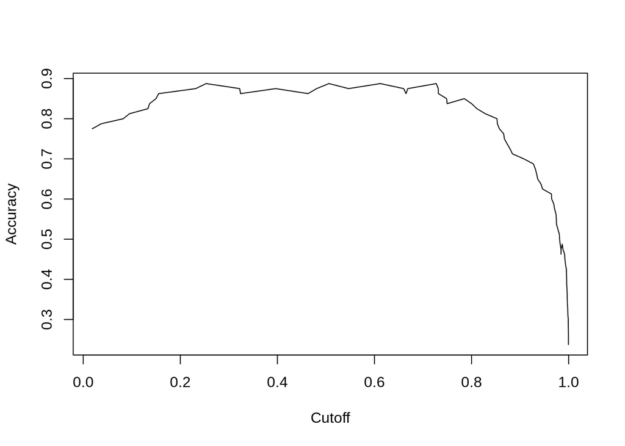

```r
pred_probts <- predict(flogisticm,tsdata,type = 'response')
pred_probts <- prediction(pred_probts,tsdata$Admit)
perf_eval <- performance(pred_probts,"acc")
plot(perf_eval)
```

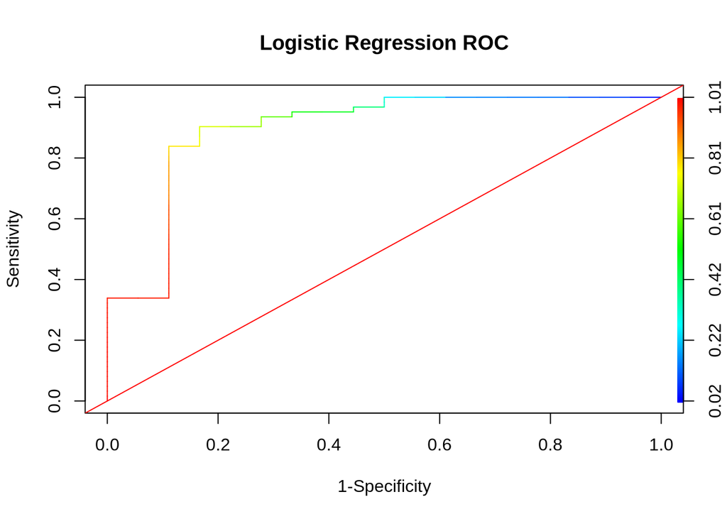

```r
ROC <- performance(pred_probts,"tpr","fpr")
plot(ROC,xlab="1-Specificity",ylab="Sensitivity",main="Logistic Regression ROC",colorize=TRUE)
abline(a=0,b=1,col="red")
```

# 10. What is the AUC? Is the accuracy of the mode good? Why or Why not?

A higher AUC indicates that the model has a better ability to distinguish between the positive and negative classes.

AUC > 0.5 suggests a better-than-random model, with higher values indicating better performance.

```r
AUC <- performance(pred_probts,"auc")
AUC<- unlist(slot(AUC,"y.values"))
AUC <- round(AUC,4)
AUC
```

```
## [1] 0.8961
```

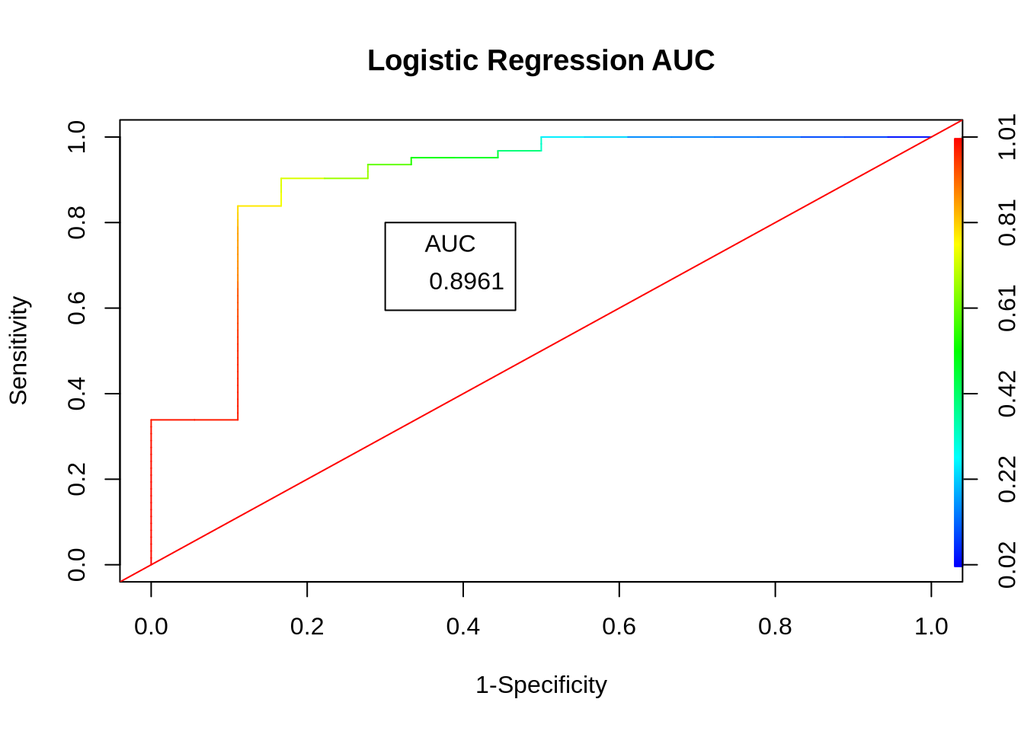

```r
plot(ROC,xlab="1-Specificity",ylab="Sensitivity",main="Logistic Regression AUC",colorize=TRUE)
abline(a=0,b=1,col="red")
legend(0.3,0.8,AUC,title="AUC",cex=1)
```